# Methylation Group Assignment Group 1

Rohit Satyam

rohit.satyam@kaust.edu.sa

May 06, 2024

This vignette outlines an analysis workflow for a DNA methylation dataset in blood monocytes from severe COVID-19 patients. The data is obtained from [Godoy-Tena et al 2022](https://genomemedicine.biomedcentral.com/articles/10.1186/s13073-022-01137-4) paper. Most of the code here is borrowed from methylationArrayAnalysis vignette [here](https://www.bioconductor.org/packages/devel/workflows/vignettes/methylationArrayAnalysis/inst/doc/methylationArrayAnalysis.html)

## 0.1 Loding required libraries

```r
setwd("/data/coursework2024/week7")
library(knitr)
library(limma)
library(minfi)
library(IlluminaHumanMethylationEPICanno.ilm10b4.hg19)
library(IlluminaHumanMethylationEPICmanifest)
library(RColorBrewer)
library(missMethyl)
library(minfiData)
library(Gviz)
library(DMRcate)
library(stringr)

# BiocManager::install("IlluminaHumanMethylationEPICanno.ilm10b4.hg19")
# BiocManager::install("IlluminaHumanMethylationEPICmanifest")
# BiocManager::install("missMethyl")
# BiocManager::install("DMRcate")
```

## 0.2 Reading the Data

```r
# reading sample sheet
targets <- read.metharray.sheet("data", pattern="Data_sheet.csv")
```

```
## [1] "data/Data_sheet.csv"
```

```r
targets$Basename <- unique(sub('data/', '', targets$Basename))

# Read the data
rgSet <- read.metharray.exp(base = "data", targets = targets)

# give the samples descriptive names
targets$Sample_Group <- gsub("Healthy Donor", "Healthy", targets$Sample_Group)
targets$ID <- paste0(targets$Sample_Group,".", targets$Sample_Name)
sampleNames(rgSet) <- targets$ID
rgSet
```

```
## class: RGChannelSet
## dim: 1051943 59
## metadata(0):
## assays(2): Green Red
## rownames(1051943): 1600101 1600111 ... 99810990 99810992
## rowData names(0):
## colnames(59): Healthy.GSM5685685 COVID19.GSM5685686 ...
##   COVID19.GSM5685742 COVID19.GSM5685743
## colData names(12): Sample_Name Sample_Well ... Basename filenames
## Annotation
##   array: IlluminaHumanMethylationEPIC
##   annotation: ilm10b4.hg19
```

## 0.3 Quality Control

Now, we calculate detection p-values, which provide an indication of signal quality. A detection p-value is generated for each CpG in every sample. Minfi calculates these p-values by comparing the total signal (M + U) `M= methylated and U= unmethylated` for each probe to the background signal, estimated from negative control probes. Very small p-values suggest a reliable signal, while larger p-values (e.g., >0.01) typically indicate poor signal quality.

Plotting the mean detection p-value for each sample helps us evaluate the overall quality of the samples in terms of signal reliability. Samples with many failed probes tend to have higher mean detection p-values.

```r
# calculate the detection p-values
detP <- detectionP(rgSet, type = "m+u")
head(detP)
```

```
##            Healthy.GSM5685685 COVID19.GSM5685686 COVID19.GSM5685687
## cg18478105       0.000000e+00       0.000000e+00       0.000000e+00
## cg09835024       0.000000e+00       0.000000e+00       0.000000e+00
## cg14361672       0.000000e+00       0.000000e+00       0.000000e+00
## cg01763666       0.000000e+00       0.000000e+00       0.000000e+00
## cg12950382       1.703791e-42      1.455376e-196      2.268351e-119
## cg02115394       0.000000e+00       0.000000e+00       0.000000e+00
##            COVID19.GSM5685688 COVID19.GSM5685689 COVID19.GSM5685690
## cg18478105                  0       0.000000e+00                  0
## cg09835024                  0       0.000000e+00                  0
## cg14361672                  0       0.000000e+00                  0
## cg01763666                  0       0.000000e+00                  0
## cg12950382                  0      1.212657e-166                  0
## cg02115394                  0       0.000000e+00                  0
##            COVID19.GSM5685691 COVID19.GSM5685692 Healthy.GSM5685693
## cg18478105       0.000000e+00       0.000000e+00       0.000000e+00
## cg09835024       0.000000e+00       0.000000e+00       0.000000e+00
## cg14361672       0.000000e+00       0.000000e+00       0.000000e+00
## cg01763666       0.000000e+00       0.000000e+00       0.000000e+00
## cg12950382      1.264801e-244      4.121817e-222      1.604882e-286
## cg02115394       0.000000e+00       0.000000e+00       0.000000e+00
##            COVID19.GSM5685694 COVID19.GSM5685695 Healthy.GSM5685696
## cg18478105                  0                  0                  0
## cg09835024                  0                  0                  0
## cg14361672                  0                  0                  0
## cg01763666                  0                  0                  0
## cg12950382                  0                  0                  0
## cg02115394                  0                  0                  0
##            COVID19.GSM5685697 COVID19.GSM5685698 COVID19.GSM5685699
## cg18478105       0.000000e+00       0.000000e+00                  0
## cg09835024       0.000000e+00       0.000000e+00                  0
## cg14361672       0.000000e+00       0.000000e+00                  0
## cg01763666       0.000000e+00       0.000000e+00                  0
## cg12950382      1.157258e-236      1.957567e-230                  0
## cg02115394       0.000000e+00       0.000000e+00                  0
##            COVID19.GSM5685700 COVID19.GSM5685701 Healthy.GSM5685702
## cg18478105       0.000000e+00       0.000000e+00                  0
## cg09835024       0.000000e+00       0.000000e+00                  0
## cg14361672       0.000000e+00       0.000000e+00                  0
## cg01763666       0.000000e+00       0.000000e+00                  0
```

[output cut: 85 more lines]

```
## cg02115394                  0       0.000000e+00       0.000000e+00
##            Healthy.GSM5685739 COVID19.GSM5685740 COVID19.GSM5685741
## cg18478105                  0       0.000000e+00                  0
## cg09835024                  0       0.000000e+00                  0
## cg14361672                  0       0.000000e+00                  0
## cg01763666                  0       0.000000e+00                  0
## cg12950382                  0      2.809165e-200                  0
## cg02115394                  0       0.000000e+00                  0
##            COVID19.GSM5685742 COVID19.GSM5685743
## cg18478105                  0       0.000000e+00
## cg09835024                  0       0.000000e+00
## cg14361672                  0       0.000000e+00
## cg01763666                  0       0.000000e+00
## cg12950382                  0      6.793546e-209
## cg02115394                  0       0.000000e+00
```

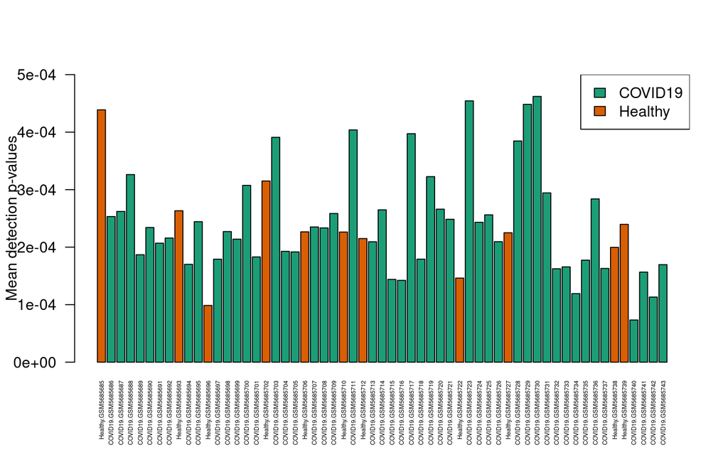

```r
# examine mean detection p-values across all samples to identify any failed samples
pal <- brewer.pal(8,"Dark2")
barplot(colMeans(detP), col=pal[factor(targets$Sample_Group)], las=2,
        cex.names=0.4, ylim=c(0,0.0005), ylab="Mean detection p-values")
abline(h=0.05,col="red")
legend("topright", legend=levels(factor(targets$Sample_Group)), fill=pal,
       bg="white")
```

```r
# check for poor quality samples, below 0.05 threshold
keep <- colMeans(detP) < 0.05 # keeping all of the samples

# remove poor quality samples
rgSet <- rgSet[,keep]

# remove poor quality samples from targets data
targets <- targets[keep,]

# generate other quality control plots
qcReport(rgSet, sampNames=targets$ID, sampGroups=targets$Sample_Group,
         pdf="qcReport.pdf")
```

All samples looks good.

## 0.4 Normalization and data exploration

We’ll use the `preprocessQuantile` method on our data. This function applies a stratified quantile normalization procedure to the methylated and unmethylated signal intensities separately, while accounting for different probe types. The M and U intensity data are then converted into M-values and beta values, along with their associated genomic coordinates.

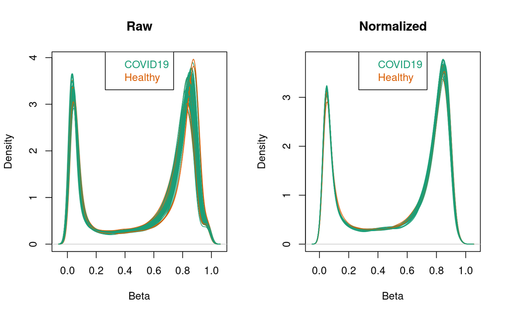

```r
# normalize the data; this results in a GenomicRatioSet object
mSetSq <- preprocessQuantile(rgSet)

# create a MethylSet object from the raw data for plotting
mSetRaw <- preprocessRaw(rgSet)

# visualise what the data looks like before and after normalization
par(mfrow=c(1,2))
densityPlot(rgSet, sampGroups=targets$Sample_Group,main="Raw", legend=FALSE)
legend("top", legend = levels(factor(targets$Sample_Group)),
       text.col=brewer.pal(8,"Dark2"))
densityPlot(getBeta(mSetSq), sampGroups=targets$Sample_Group,
            main="Normalized", legend=FALSE)
legend("top", legend = levels(factor(targets$Sample_Group)),
       text.col=brewer.pal(8,"Dark2"))
```

Now let’s make Multi-dimensional scaling (MDS) plots, based on principal components analysis which are exploratory plots. The plots below reveal similarities and differences between samples, with similar samples clustering together and dissimilar samples appearing farther apart. The first dimension (principal component 1) captures the most significant source of variation, while subsequent dimensions capture decreasing sources of variation.

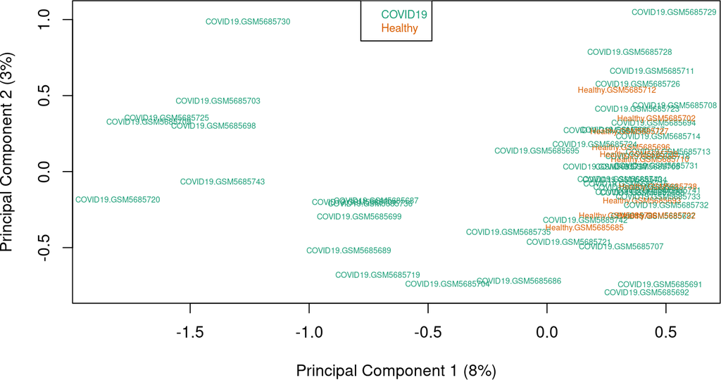

```r
# MDS plots to look at largest sources of variation


plotMDS(getM(mSetSq), top=1000, gene.selection="common", labels = NULL,
        col=pal[factor(targets$Sample_Group)], cex = 0.5)
legend("top", legend=levels(factor(targets$Sample_Group)), text.col=pal,
       bg="white", cex=0.7)
```

## 0.5 Filtering

Probes with poor performance are typically removed before conducting differential methylation analysis. Since these probes yield unreliable signals, eliminating them reduces the number of statistical tests, thereby lowering the multiple testing penalty. We exclude probes that have failed in one or more samples based on detection p-values, and also filter out probes located at SNPs and on sex chromosomes.

```r
# ensure probes are in the same order in the mSetSq and detP objects
detP <- detP[match(featureNames(mSetSq),rownames(detP)),]

# remove any probes that have failed in one or more samples
keep <- rowSums(detP < 0.01) == ncol(mSetSq)
table(keep)
```

```
## keep
##  FALSE   TRUE
##   6849 859010
```

```r
mSetSqFlt <- mSetSq[keep,]
mSetSqFlt
```

```
## class: GenomicRatioSet
## dim: 859010 59
## metadata(0):
## assays(2): M CN
## rownames(859010): cg14817997 cg26928153 ... cg07587934 cg16855331
## rowData names(0):
## colnames(59): Healthy.GSM5685685 COVID19.GSM5685686 ...
##   COVID19.GSM5685742 COVID19.GSM5685743
## colData names(15): Sample_Name Sample_Well ... yMed predictedSex
## Annotation
##   array: IlluminaHumanMethylationEPIC
##   annotation: ilm10b4.hg19
## Preprocessing
##   Method: Raw (no normalization or bg correction)
##   minfi version: 1.51.0
##   Manifest version: 0.3.0
```

```r
# remove probes with SNPs at CpG site
mSetSqFlt <- dropLociWithSnps(mSetSqFlt)
mSetSqFlt
```

```
## class: GenomicRatioSet
## dim: 830573 59
## metadata(0):
## assays(2): M CN
## rownames(830573): cg14817997 cg26928153 ... cg07587934 cg16855331
## rowData names(0):
## colnames(59): Healthy.GSM5685685 COVID19.GSM5685686 ...
##   COVID19.GSM5685742 COVID19.GSM5685743
## colData names(15): Sample_Name Sample_Well ... yMed predictedSex
## Annotation
##   array: IlluminaHumanMethylationEPIC
##   annotation: ilm10b4.hg19
## Preprocessing
##   Method: Raw (no normalization or bg correction)
##   minfi version: 1.51.0
##   Manifest version: 0.3.0
```

```r
# Remove probes on the sex chromosomes
# creating the annotation
annEPIC <- getAnnotation(IlluminaHumanMethylationEPICanno.ilm10b4.hg19)

keep <- !(featureNames(mSetSqFlt) %in% annEPIC$Name[annEPIC$chr %in% c("chrX","chrY")])
table(keep)
```

```
## keep
##  FALSE   TRUE
##  18683 811890
```

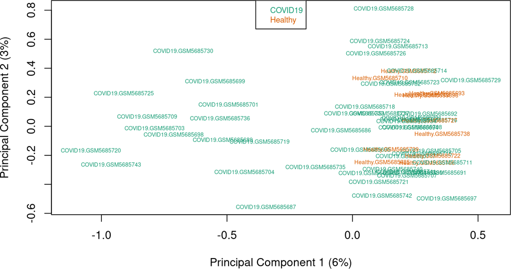

```r
mSetSqFlt <- mSetSqFlt[keep,]

# plot MDS after filtering
plotMDS(getM(mSetSqFlt), top=1000, gene.selection="common", labels = NULL,
        col=pal[factor(targets$Sample_Group)], cex = 0.5)
legend("top", legend=levels(factor(targets$Sample_Group)), text.col=pal,
       bg="white", cex=0.7)
```

```r
gc()
```

```
##             used   (Mb) gc trigger   (Mb)   max used   (Mb)
## Ncells  22164440 1183.8   41267215 2204.0   26201236 1399.3
## Vcells 632414389 4825.0 1099094442 8385.5 1080590803 8244.3
```

## 0.6 Probe-wise differential methylation analysis

The biological question of interest for this particular dataset is to discover differentially methylated probes between the covid and healthy samples.

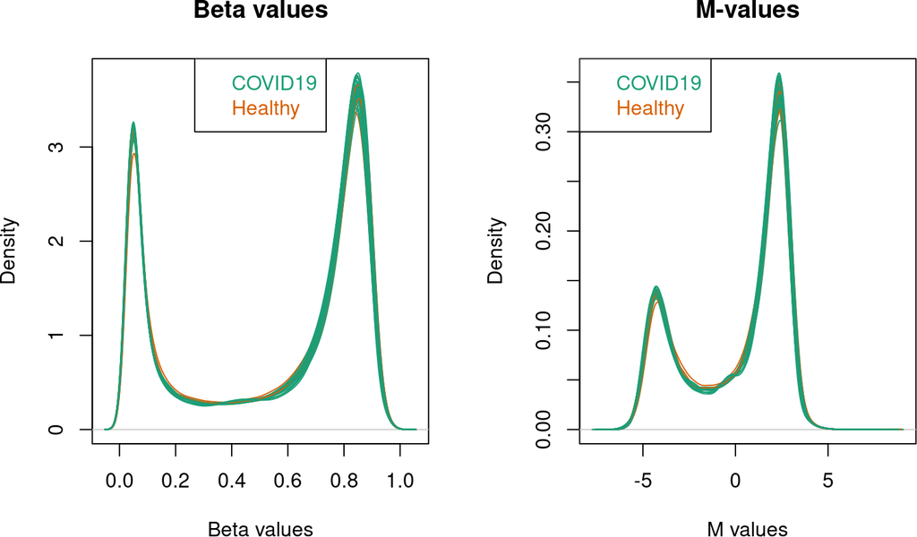

```r
# calculate M-values for statistical analysis
mVals <- getM(mSetSqFlt)

bVals <- getBeta(mSetSqFlt)

#Plotting m and b values
par(mfrow=c(1,2))
densityPlot(bVals, sampGroups=targets$Sample_Group, main="Beta values",
            legend=FALSE, xlab="Beta values")
legend("top", legend = levels(factor(targets$Sample_Group)),
       text.col=brewer.pal(8,"Dark2"))
densityPlot(mVals, sampGroups=targets$Sample_Group, main="M-values",
            legend=FALSE, xlab="M values")
legend("topleft", legend = levels(factor(targets$Sample_Group)),
       text.col=brewer.pal(8,"Dark2"))
```

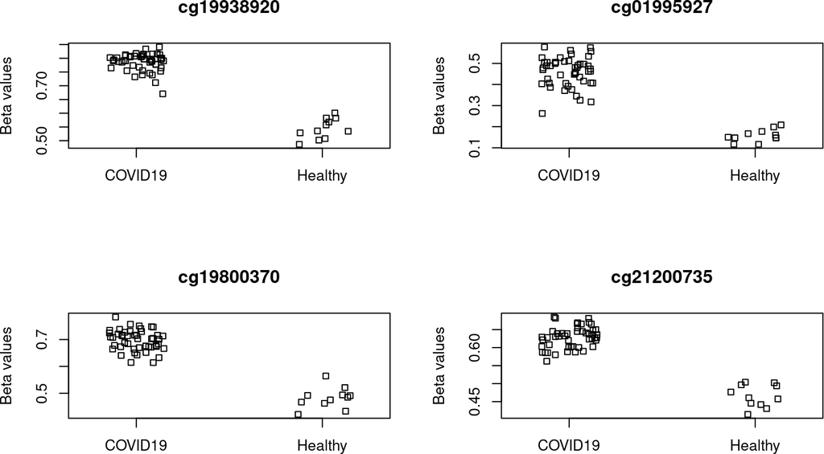

```r
cellType <- factor(targets$Sample_Group, levels = c('Healthy', 'COVID19'))

# create a design matrix
design <- model.matrix(~ 0 + cellType, data = targets)
colnames(design) <- gsub("cellType", "", colnames(design))

# create a contrast matrix for specific comparisons
contMatrix <- makeContrasts(COVID19-Healthy,
                            levels=design)
# linear model
fit <- lmFit(mVals, design)

# fit the contrasts
fit2 <- contrasts.fit(fit, contMatrix)
fit2 <- eBayes(fit2)


# get the table of results for the first contrast (COVID19 - Healthy)
annSub <- annEPIC[match(rownames(mVals),annEPIC$Name),
                      c(1:4,12:19,24:ncol(annEPIC))]
# DMP results
DMPs <- topTable(fit2, num=Inf, coef=1, genelist=annSub)
write.table(DMPs, file="DMPs.csv", sep=",", row.names=FALSE)

# plot the top 4 most significantly differentially methylated CpGs
par(mfrow=c(2,2))
sapply(rownames(DMPs)[1:4], function(cpg){
  plotCpg(bVals, cpg=cpg, pheno=targets$Sample_Group, ylab = "Beta values")
})
```

```r
gc()
```

```
##             used   (Mb) gc trigger   (Mb)   max used   (Mb)
## Ncells  22203964 1185.9   41267215 2204.0   26201236 1399.3
## Vcells 761536217 5810.1 1099094442 8385.5 1099056921 8385.2
```

## 0.7 Differential methylation analysis of regions

```r
myAnnotation <- cpg.annotate(object = mVals, datatype = "array", what = "M",
                             analysis.type = "differential", design = design,
                             contrasts = TRUE, cont.matrix = contMatrix,
                             coef = "COVID19 - Healthy", arraytype = "EPICv1")

DMRs <- dmrcate(myAnnotation, lambda=1000, C=2)
results.ranges <- extractRanges(DMRs)
results.ranges
```

```
## GRanges object with 6884 ranges and 8 metadata columns:
##          seqnames              ranges strand |   no.cpgs min_smoothed_fdr
##             <Rle>           <IRanges>  <Rle> | <integer>        <numeric>
##      [1]    chr22   45608023-45610480      * |        17     1.03290e-254
##      [2]     chr1   25290947-25292412      * |        16     8.45443e-134
##      [3]    chr12     6745057-6748130      * |        19     8.24427e-137
##      [4]    chr12     6657167-6659770      * |        14     4.41506e-148
##      [5]     chr5 149466066-149467244      * |         8     2.05899e-124
##      ...      ...                 ...    ... .       ...              ...
##   [6880]     chr6   29698405-29698518      * |         2      1.22827e-04
##   [6881]    chr11     2890419-2891118      * |        24      3.58053e-05
##   [6882]    chr19   49828787-49828833      * |         2      1.47265e-04
##   [6883]     chr6   32134865-32135129      * |        10      1.37068e-04
##   [6884]     chr2   27850623-27850661      * |         2      9.21471e-05
##             Stouffer       HMFDR       Fisher     maxdiff     meandiff
```

[output cut: 27 more lines]

[figure not shown]

```r
groups <- pal[1:length(unique(targets$Sample_Group))]
names(groups) <- levels(factor(targets$Sample_Group))
cols <- groups[as.character(factor(targets$Sample_Group))]

# DMR.plot(ranges = results.ranges, dmr = 2, CpGs = bVals, phen.col = cols,
#          what = "Beta", arraytype = "450K", genome = "hg19")
```

## Gene Ontology

```r
sigCpGs <- DMPs$Name[DMPs$adj.P.Val<0.05]
sigCpGs[1:10]# First 10 significant CpGs
```

```
##  [1] "cg19938920" "cg01995927" "cg19800370" "cg21200735" "cg23698960"
##  [6] "cg24518693" "cg19711949" "cg11099984" "cg22434506" "cg25392060"
```

```r
length(sigCpGs)
```

```
## [1] 35232
```

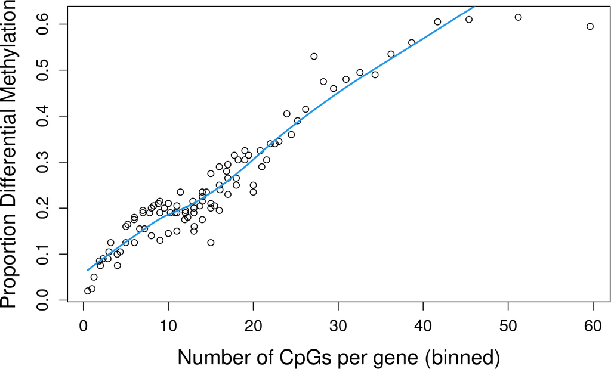

```r
par(mfrow=c(1,1))
gst <- gometh(sig.cpg=sigCpGs, plot.bias=TRUE)
```

```r
topGSA(gst, number=10)
```

```
##            ONTOLOGY                                             TERM    N  DE
## GO:0006955       BP                                  immune response 1695 640
## GO:0002376       BP                            immune system process 2481 905
## GO:0001775       BP                                  cell activation 1084 454
## GO:0045321       BP                             leukocyte activation  935 399
## GO:0002684       BP     positive regulation of immune system process 1055 413
## GO:0046649       BP                            lymphocyte activation  772 329
## GO:0002252       BP                          immune effector process  616 255
## GO:0002682       BP              regulation of immune system process 1516 551
## GO:0002366       BP leukocyte activation involved in immune response  286 141
## GO:0006952       BP                                 defense response 1786 596
##                    P.DE          FDR
## GO:0006955 1.289907e-29 2.904870e-25
## GO:0002376 5.490565e-29 6.182377e-25
## GO:0001775 3.488259e-23 2.618520e-19
## GO:0045321 1.844296e-22 1.038339e-18
## GO:0002684 6.452732e-18 2.906310e-14
## GO:0046649 1.286158e-17 4.827381e-14
## GO:0002252 1.368290e-16 4.132389e-13
## GO:0002682 1.467989e-16 4.132389e-13
## GO:0002366 5.997108e-16 1.500610e-12
## GO:0006952 8.209362e-16 1.848748e-12
```

## 0.8 Differential variability

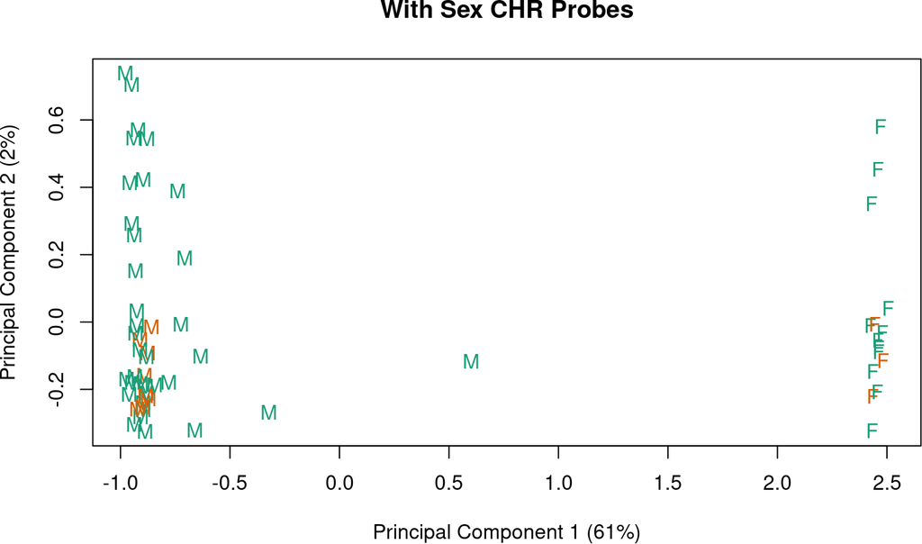

```r
detP <- detectionP(rgSet, type = "m+u")
mSetSq <- preprocessQuantile(rgSet)


targets$Sex <- getSex(mSetSq)$predictedSex
detP <- detP[match(featureNames(mSetSq),rownames(detP)),]

keep <- rowSums(detP < 0.01) == ncol(detP)
mSetSqFlt <- mSetSq[keep,]
mSetSqFlt <- dropLociWithSnps(mSetSqFlt, snps = c("CpG", "SBE"))

plotMDS(getM(mSetSqFlt), top=1000, gene.selection="common",
        col=pal[factor(targets$Sample_Group)], labels=targets$Sex,
        main="With Sex CHR Probes")
```

```r
# get M-values for analysis
mVals <- getM(mSetSqFlt)

design <- model.matrix(~factor(targets$Sample_Group))
fitvar <- varFit(mVals, design = design, coef = c(1,2))

# Summary of differential variability
summary(decideTests(fitvar))
```

```
##        (Intercept) factor(targets$Sample_Group)Healthy
## Down             0                                  24
## NotSig          18                              830220
## Up          830555                                 329
```

```r
topDV <- topVar(fitvar, coef=2)
topDV
```

```
##            SampleVar LogVarRatio DiffLevene         t      P.Value  Adj.P.Value
## cg20648333 0.3908892    3.537077  0.9369662 10.028893 1.997933e-17 1.160795e-11
## cg23595055 0.5285544    3.468363  1.0331636  9.966990 2.795167e-17 1.160795e-11
## cg03224850 0.2092742    3.001342  0.6427816  9.799324 6.935778e-17 1.920223e-11
## cg04407652 0.3877536    2.464585  0.7644776  7.270850 4.498597e-11 9.341033e-06
## cg05705964 0.2684289    2.519195  0.6564096  6.959699 2.163217e-10 3.593419e-05
## cg15208524 0.9892284    1.684197  1.0686443  6.756691 5.943789e-10 8.227917e-05
## cg18113826 0.4191358    2.931363  0.7638115  6.728221 1.246254e-09 1.376216e-04
## cg08362785 0.1860853    2.664049  0.3451952  6.968773 1.325558e-09 1.376216e-04
## cg04877503 0.3848094    1.756546  0.6476104  6.546159 1.674161e-09 1.417082e-04
## cg20376123 0.1344428    1.964705  0.4186472  6.542285 1.706150e-09 1.417082e-04
```

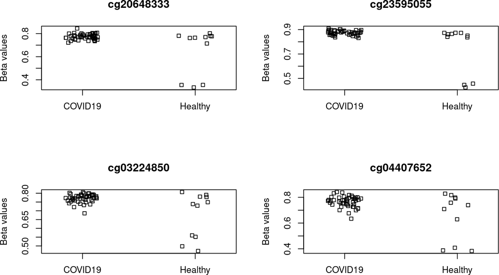

```r
bVals <- getBeta(mSetSqFlt)
par(mfrow=c(2,2))
sapply(rownames(topDV)[1:4], function(cpg){
  plotCpg(bVals, cpg=cpg, pheno=targets$Sample_Group,
          ylab = "Beta values")})
```

## 0.9 Inference

**Differential Methylation Pattern analysis revealed**: - Significant methylation differences at sites like cg19938920 and cg01995927, which are located in genes involved in immune modulation. - These epigenetic changes may impact gene expression, potentially contributing to the abnormal immune responses observed in severe COVID-19 patients by affecting monocyte function and increasing inflammation.

**Gene Ontology Testing showed**: - Significant enrichment in pathways such as “immune response” and “leukocyte activation.” - This suggests that epigenetic modifications in severe COVID-19 may prime leukocytes toward a hyperactivated state, potentially exacerbating inflammation and tissue damage.

**Potential Impact on Monocyte Differentiation**: - Observed methylation changes could influence monocyte differentiation, potentially skewing development towards more inflammatory subtypes or those less capable of resolving inflammation. - This shift might play a significant role in the pathology of severe COVID-19 by affecting the immune system’s response to the virus.